# ProbitTheory

Arnav Gupta

2026-04-25

## Probit Regression Theory

##New Slide

### Step 1: Linear Predictor

$$\eta_i = x_i^\top \beta$$

```r
eta <- X %*% beta
```

The linear predictor is passed through a standard normal CDF to convert it to a probability

##New Slide

### Step 2: Linear Predictor –> Probability

$$\hat{p}_i = \Phi(\eta_i) \quad \text{and} \quad \hat{q}_i = \phi(\eta_i)$$

```r
phat <- pnorm(eta)
qhat <- dnorm(eta)
```

Using the linear predictor, $\hat{p}_i = \Phi(\eta_i)$ converts it into a probability between 0 and 1 for $Y_i = 1$, while $\hat{q}_i = \phi(\eta_i)$ indicates the rate of change of that probability with respect to the linear predictor at that point.

##New Slide

### Step 3: Score Vector

$$s(\beta) = \sum_{i=1}^{N} \frac{\phi(x_i^\top \beta)}{\Phi(x_i^\top
\beta)\left(1 - \Phi(x_i^\top \beta)\right)} \left(y_i - \Phi(x_i^\top
\beta)\right) x_i$$

$$\frac{\phi(\eta_i)}{\Phi(\eta_i)\big(1 - \Phi(\eta_i)\big)}
\times (y_i - \Phi(\eta_i))
\times x_{ij}$$

The score function tells us in which direction should the coefficients $\beta$ to increase the probability of observing the data (dependent variable) given the parameters (independent variables).

```r
ratio <- qhat / (phat * (1 - phat))
score <- (y - phat) * ratio
g     <- t(X) %*% score
```

##New Slide

The score function has three components.

**Ratio:** tells us how sensitive the model is at that point $\eta_i = x_i^\top \beta$. At the start of the estimation, the coefficients $\beta$ are initialized to 0. At this point, the predicted probability of all events is 0.5, meaning the model adjusts to errors and is positioned to learn.

**Residual:** compares what actually happened $y_i$ = 0 or 1 with the predicted probability. If it is positive, the model predicted too low. If it is negative, the model predicted too high.

**Gradient:** tells the model both the **direction** (increase or decrease a coefficient) and the **magnitude** of adjustment needed so that predicted probabilities better align with the observed data.

$$\eta_i = x_i^\top \beta$$

$$\frac{\partial \eta_i}{\partial \beta_j} = x_{ij}$$

##New Slide

### Step 4: Hessian

The weights tell the model to focus on observations that are hardest to classify (those with predicted probabilities near 0.5 ex. initialization), and the Hessian uses this information to determine how large a step to take when updating the coefficients.

$$\mathbf{H} = -\mathbf{X}^\top \mathbf{W} \mathbf{X}$$

$$w_i = \frac{\phi(\eta_i)^2}{\Phi(\eta_i)(1 - \Phi(\eta_i))}$$

```r
w <- (qhat^2) / (phat * (1 - phat))
H <- -t(X) %*% (X * as.vector(w))
```

##New Slide

### Step 5: Newton-Raphson Update

$$\theta_{new} = \theta_{old} - [\text{Hessian}]^{-1} \times
[\text{Gradient}]$$

$$\beta^{(t+1)} = \beta^{(t)} - \mathbf{H}(\beta^{(t)})^{-1}
s(\beta^{(t)})$$

The algorithm looks at three things:

1. Where it is now $\beta^{(t)}$
2. Which direction improves the model? **The gradient**
3. How aggressive the move in the direction should be? **The Hessian**

The new coefficients represent the difference between the previous coefficients and the new curvature adjusted step.

```r
beta <- beta - solve(H, g)
```

The computer is repeating the same update step over and over, each time improving the coefficients, until they stop changing.

##New Slide

## MtCars Implementation

**Research Question:** What is the relationship between a car’s fuel efficiency (MPG) and the probability that it has a manual transmission?

```r
data(mtcars)

X <- model.matrix(am ~ mpg, data = mtcars)
y <- mtcars$am

beta <- c(0, 0)   # initial coefficients
```

We initialized the coefficients to zero, representing a neutral starting point for the regression process.

##New Slide

### Step 1: Linear Predictor

```r
eta <- X %*% beta

print(head(eta))
```

```
                  [,1]
Mazda RX4            0
Mazda RX4 Wag        0
Datsun 710           0
Hornet 4 Drive       0
Hornet Sportabout    0
Valiant              0
```

All values = 0 - model has no information yet

##New Slide

### Step 2: Linear Predictor –> Probability

```r
phat <- pnorm(eta)
qhat <- dnorm(eta)

print(head(phat))
```

```
                  [,1]
Mazda RX4          0.5
Mazda RX4 Wag      0.5
Datsun 710         0.5
Hornet 4 Drive     0.5
Hornet Sportabout  0.5
Valiant            0.5
```

```r
print(head(qhat))
```

```
                       [,1]
Mazda RX4         0.3989423
Mazda RX4 Wag     0.3989423
Datsun 710        0.3989423
Hornet 4 Drive    0.3989423
Hornet Sportabout 0.3989423
Valiant           0.3989423
```

Interpretation:

- phat = 0.5 - model is completely uncertain

- qhat ≈ 0.399 - maximum sensitivity to change

##New Slide

### Step 3: Score Vector

```r
ratio <- qhat / (phat * (1 - phat))
score <- (y - phat) * ratio
g     <- t(X) %*% score

print(head(ratio))
```

```
                      [,1]
Mazda RX4         1.595769
Mazda RX4 Wag     1.595769
Datsun 710        1.595769
Hornet 4 Drive    1.595769
Hornet Sportabout 1.595769
Valiant           1.595769
```

```r
print(head(score))
```

```
                        [,1]
Mazda RX4          0.7978846
Mazda RX4 Wag      0.7978846
Datsun 710         0.7978846
Hornet 4 Drive    -0.7978846
Hornet Sportabout -0.7978846
Valiant           -0.7978846
```

```r
print(g)
```

```
                 [,1]
(Intercept) -4.787307
mpg         -6.941596
```

Ratio ≈ 1.596 → model is responsive to errors

Positive Score → model underpredicts (needs to increase probability)

Negative Score → model overpredicts (needs to decrease probability)Interpretation:

- Beta0 gradient: -4.787307 → overall adjustment to baseline i.e. model less likely to be manual (1)

##New Slide

### Step 4: Hessian

```r
w <- (qhat^2) / (phat * (1 - phat))
H <- -t(X) %*% (X * as.vector(w))

print(head(w))
```

```
                       [,1]
Mazda RX4         0.6366198
Mazda RX4 Wag     0.6366198
Datsun 710        0.6366198
Hornet 4 Drive    0.6366198
Hornet Sportabout 0.6366198
Valiant           0.6366198
```

```r
print(H)
```

```
            (Intercept)        mpg
(Intercept)   -20.37183  -409.2829
mpg          -409.28285 -8939.6122
```

Weight Interpretation: All weights equal → every observation equally important at start

##New Slide

### Step 5: Newton-Raphson Update

```r
beta_new <- beta - solve(H, g)

print(beta_new)
```

```
                  [,1]
(Intercept) -2.7359666
mpg          0.1244844
```

Interpretation:

- Beta0 is negative → baseline probability of manual is low

- Beta1 is positive → higher mpg increases probability of manual

The computer is repeating the same update step over and over, each time improving the coefficients, until they stop changing.

##New Slide

#### Our Implementation of Probit Regresion:

```r
myprobit = function(X, y, max_iter, tolerance, verbose=FALSE){

  m = ncol(X)
  beta <- rep(0, m)

  for (i in 1:max_iter) {

    eta <- X %*% beta

    phat <- pnorm(eta)
    qhat <- dnorm(eta)

    ratio <- qhat / (phat * (1 - phat))
    score <- (y - phat) * ratio
    g <- t(X) %*% score

    w <- (qhat^2) / (phat * (1 - phat))
    H <- -t(X) %*% (X * as.vector(w))

    copy_beta = beta
    beta <- beta - solve(H, g)

    if (verbose){
      cat("Iteration", i, ":\n")
      j=1
      for (b in beta){
        cat("Beta", j, " = ", beta[j], "\n")
        j=j+1
      }
    }
    if ((sum(beta - copy_beta)^2) < tolerance) {
        return(beta)
        break
      }
  }
}

X <- model.matrix(am ~ mpg, data = mtcars)
y <- mtcars$am
myprobit(X,y,32, 0.00009, FALSE)
```

```
                  [,1]
(Intercept) -3.9100663
mpg          0.1822605
```

##New Slide: Verifying with R’s in-built function

```r
modell <- coef(glm(am ~ mpg, data = mtcars, family = binomial(link="probit")))
modell
```

```
(Intercept)         mpg
 -3.9102065   0.1822684
```

- Intercept **(−3.91)** represents the baseline latent tendency for a car to be manual when MPG is zero; it is strongly negative, meaning the model starts from a situation where automatic transmission is much more likely before considering MPG.

- The MPG coefficient **(0.182)** means that each additional unit of MPG increases the latent “manual likelihood” score, shifting the probability toward a manual transmission.

##New Slide

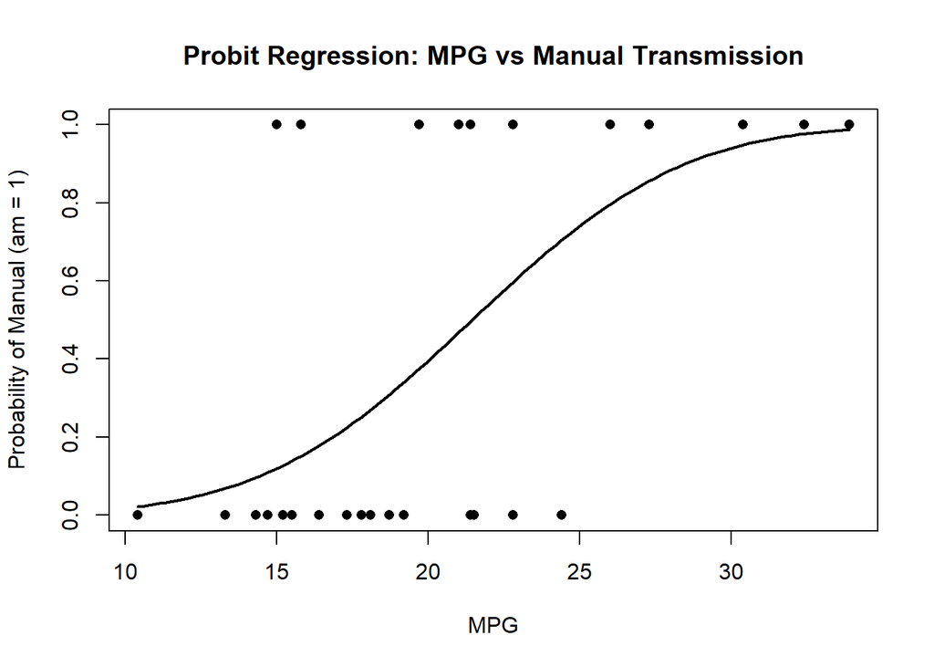

There is a positive relationship between MPG and the probability that a car has a manual transmission: as fuel efficiency increases, the likelihood that a car is manual increases.

##New Slide

```r
library(margins)
mfx <- margins(model)
summary(mfx)
```

```
 factor    AME     SE      z      p  lower  upper
    mpg 0.0470 0.0080 5.8607 0.0000 0.0313 0.0628
```

To answer our research question, what is the relationship between a car’s fuel efficiency (MPG) and the probability that it has a manual transmission, for each 1 MPG increase, the probability that a car is manual increases by about 4.7 percentage points (on average).

##NewSlide

### Extension

When extending the probit model to include multiple predictors, the structure of the model remains unchanged:

$$P(y=1) = \Phi(\beta_0 + \beta_1 \cdot \text{mpg} + \beta_2 \cdot
\text{wt})$$

Each coefficient represents a partial effect, meaning that the effect of one variable is measured while holding the other variables constant.

If we add weight to the model, the MPG coefficient captures its effect on transmission probability while holding weight constant—meaning it reflects MPG’s independent contribution rather than differences driven by weight.

##New Slide

### Government/Politics Dataset

**Research question**: to what extent do socioeconomic factors, specifically age, education, and income, predict voter turnout in American national elections?

##New Slide

Translating information from the codebook, we considered the variables below.

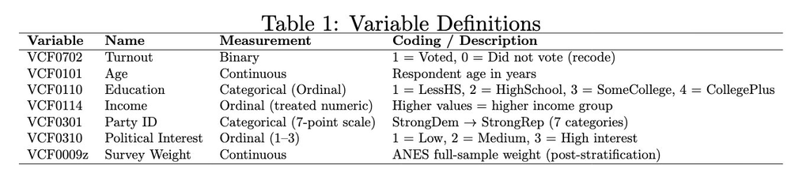

```r
knitr::include_graphics("img/DataTable.jpg")
```

VCF0009z, considers if a survey accidentally talks to too many men and not enough women, the women’s answers are given a higher weight (they count for more than one person) and the men’s answers are given a lower weight (they count for less than one person).

We cleaned the dataset to only use the variables above

##New Slide

#### Exploratory Data Analysis

```r
chisq.test(table(df_clean$vote, df_clean$education))
```

```
    Pearson's Chi-squared test

data:  table(df_clean$vote, df_clean$education)
X-squared = 3910.4, df = 3, p-value < 2.2e-16
```

```r
chisq.test(table(df_clean$vote, df_clean$party_id))
```

```
    Pearson's Chi-squared test

data:  table(df_clean$vote, df_clean$party_id)
X-squared = 3694.5, df = 6, p-value < 2.2e-16
```

- For education, the test statistic is very large $X^2 = 3910.4$ with a p-value effectively equal to zero. We can confidently reject the idea that voting behavior is independent of education level.

- For party identification, the chi-squared test $X^2 = 3694.5$ also produces a near-zero p-value, indicating a strong relationship between party ID and turnout.

##New Slide

```
Warning in eval(family$initialize): non-integer #successes in a binomial glm!
```

```
Call:
glm(formula = vote ~ age + education + income + party_id + interest,
    family = binomial(link = "probit"), data = df_clean, weights = weight)

Coefficients:
                       Estimate Std. Error z value Pr(>|z|)
(Intercept)          -1.2271752  0.0323903  -37.89   <2e-16 ***
age                   0.0145019  0.0003513   41.28   <2e-16 ***
educationSomeCollege -0.2651494  0.0191872  -13.82   <2e-16 ***
educationHighSchool  -0.5935501  0.0171903  -34.53   <2e-16 ***
educationLessHS      -0.8753739  0.0229323  -38.17   <2e-16 ***
income                0.1417566  0.0047471   29.86   <2e-16 ***
party_idIndLeanDem    0.3025451  0.0226679   13.35   <2e-16 ***
party_idIndLeanRep    0.3480854  0.0235716   14.77   <2e-16 ***
party_idWeakDem       0.3703462  0.0201312   18.40   <2e-16 ***
party_idWeakRep       0.4335910  0.0221265   19.60   <2e-16 ***
party_idStrongDem     0.6847337  0.0212788   32.18   <2e-16 ***
party_idStrongRep     0.7786772  0.0244692   31.82   <2e-16 ***
interest              0.4008260  0.0075930   52.79   <2e-16 ***
---
Signif. codes:  0 '***' 0.001 '**' 0.01 '*' 0.05 '.' 0.1 ' ' 1

(Dispersion parameter for binomial family taken to be 1)

    Null deviance: 74508  on 61812  degrees of freedom
Residual deviance: 61211  on 61800  degrees of freedom
AIC: 60653

Number of Fisher Scoring iterations: 4
```

Latent scores.

##New Slide

```r
mfx <- margins(model1)
summary(mfx)
```

```
               factor     AME     SE        z      p   lower   upper
                  age  0.0039 0.0001  43.1511 0.0000  0.0037  0.0041
  educationHighSchool -0.1548 0.0041 -37.3483 0.0000 -0.1629 -0.1466
      educationLessHS -0.2449 0.0065 -37.5029 0.0000 -0.2577 -0.2321
 educationSomeCollege -0.0621 0.0044 -13.9750 0.0000 -0.0708 -0.0534
               income  0.0381 0.0013  30.1869 0.0000  0.0356  0.0405
             interest  0.1076 0.0019  56.2491 0.0000  0.1039  0.1114
   party_idIndLeanDem  0.0947 0.0071  13.3597 0.0000  0.0808  0.1086
   party_idIndLeanRep  0.1080 0.0073  14.8308 0.0000  0.0938  0.1223
    party_idStrongDem  0.1975 0.0063  31.4816 0.0000  0.1852  0.2098
    party_idStrongRep  0.2192 0.0068  32.4330 0.0000  0.2059  0.2324
      party_idWeakDem  0.1145 0.0063  18.1659 0.0000  0.1021  0.1268
      party_idWeakRep  0.1324 0.0068  19.5564 0.0000  0.1191  0.1456
```

The average marginal effect (AME) of 0.0039 means that each additional year of age increases the probability of voting by about **0.4 percentage points**, holding other factors constant. This suggests that older individuals are more likely to vote.

Compared to individuals with a college degree (the baseline group), those with lower levels of education are significantly less likely to vote. For example, having only a high school education decreases the probability of voting by about **15.5 percentage points**

The AME of 0.0381 shows that moving up one income category increases the probability of voting by about **3.8 percentage points**.

Compared to independents, individuals who identify with a political party, especially strong partisans, are substantially more likely to vote. For example, strong Democrats and strong Republicans are about **20–22 percentage points more likely** to vote than independents.

Similarly, **political interest** has one of the largest effects in the model. The average marginal effect of 0.1076 indicates that moving up one level of interest increases the probability of voting by about **10.8 percentage points**.

Overall, while socioeconomic resources are important, these results show that political engagement and partisan identity are equally powerful predictors of turnout.

## Appendix Code

```r
model <- glm(am ~ mpg,
             data = mtcars,
             family = binomial(link = "probit"))

mpg_seq <- seq(min(mtcars$mpg), max(mtcars$mpg), length.out = 100)

pred_prob <- predict(model, newdata = data.frame(mpg = mpg_seq), type = "response")

plot(mtcars$mpg, mtcars$am,
     xlab = "MPG",
     ylab = "Probability of Manual (am = 1)",
     main = "Probit Regression: MPG vs Manual Transmission",
     pch = 16)

lines(mpg_seq, pred_prob, lwd = 2)
```

```r
df <- read.csv("anes_cleaned.csv", stringsAsFactors = FALSE)


vars <- c("VCF0702",  # turnout
          "VCF0101",  # age
          "VCF0110",  # education
          "VCF0114",  # income
          "VCF0301",  # party ID
          "VCF0310",  # political interest
          "VCF0009z") # weights

df_clean <- df[, vars]

df_clean[df_clean < 0] <- NA

# Dependent Variable: Turnout (1 = voted, 0 = did not vote)
df_clean$vote <- ifelse(df_clean$VCF0702 == 2, 1,
                  ifelse(df_clean$VCF0702 == 1, 0, NA))

df_clean$age <- as.numeric(df_clean$VCF0101)

df_clean$education <- factor(df_clean$VCF0110,
                            levels = c(4,3,2,1),
                            labels = c("CollegePlus", "SomeCollege", "HighSchool", "LessHS"))

df_clean$income <- as.numeric(df_clean$VCF0114)

df_clean$party_id <- factor(df_clean$VCF0301,
                           levels = c(4,3,5,2,6,1,7),
                           labels = c("Independent",
                                      "IndLeanDem",
                                      "IndLeanRep",
                                      "WeakDem",
                                      "WeakRep",
                                      "StrongDem",
                                      "StrongRep"))

df_clean$interest <- as.numeric(df_clean$VCF0310)

df_clean$weight <- df_clean$VCF0009z


df_clean <- na.omit(df_clean)
```

```r
model <- glm(am ~ mpg,
             data = mtcars,
             family = binomial(link = "probit"))

mpg_seq <- seq(min(mtcars$mpg), max(mtcars$mpg), length.out = 100)

pred_prob <- predict(model, newdata = data.frame(mpg = mpg_seq), type = "response")

plot(mtcars$mpg, mtcars$am,
     xlab = "MPG",
     ylab = "Probability of Manual (am = 1)",
     main = "Probit Regression: MPG vs Manual Transmission",
     pch = 16)

lines(mpg_seq, pred_prob, lwd = 2)
```